```r
library(tidyverse)
library(here)
library(ggthemes)
library(MatchIt)
library(haven)

thomas_version_d <- read_csv("triad_diff.csv") %>% janitor::clean_names()
anjie_version_d <- read_csv("anjie_triad.csv")
d <- read_sav(here("data/State Rice Farm Data.sav"))
```

ok looks like some are the same some are different

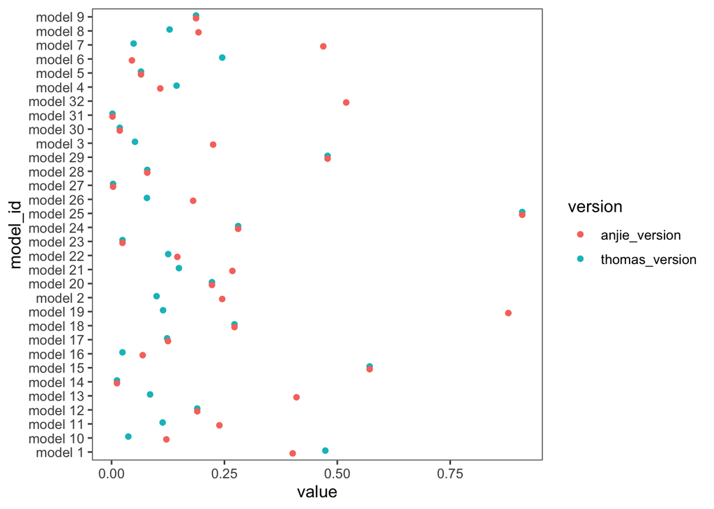

```r
thomas_version_d %>%
  mutate(
    model = paste0("y ~ ", variables_used_in_matching_and_as_controls,  " + RiceFarm")
  ) %>%
  right_join(anjie_version_d, by = "model") %>%
  rename(
    thomas_version = rice_farm_p_value,
    anjie_version = p.value

  ) %>%
  mutate(model_id = paste0("model ", row_number())) %>%
  select(model_id, thomas_version, anjie_version) %>%
  pivot_longer(
    cols = c("thomas_version", "anjie_version"),
    names_to = "version",
    values_to = "value"
  ) %>%
  mutate(is_significant = (value < .05)) %>%
  ggplot(aes(x = model_id, y = value, color = version)) +
  geom_point(position = position_dodge(width = .4)) +
  coord_flip() +
  theme_few()
```

what are the same ones?

ok so coarsely it looks like everything with motherEducation was ok? interesting lol

```r
thomas_version_d %>%
  mutate(
    model = paste0("y ~ ", variables_used_in_matching_and_as_controls,  " + RiceFarm")
  ) %>%
  right_join(anjie_version_d, by = "model") %>%
  rename(
    thomas_version = rice_farm_p_value,
    anjie_version = p.value

  ) %>%
   select(model, thomas_version, anjie_version) %>%
  filter(abs(thomas_version - anjie_version) < 0.0000001)
```

```
## # A tibble: 15 × 3
##    model                                            thomas_version anjie_version
##    <chr>                                                     <dbl>         <dbl>
##  1 y ~ MotherEducation + RiceFarm                          0.0652        0.0652
##  2 y ~ Female + MotherEducation + RiceFarm                 0.187         0.187
##  3 y ~ Age + MotherEducation + RiceFarm                    0.190         0.190
##  4 y ~ Hui + MotherEducation + RiceFarm                    0.0119        0.0119
##  5 y ~ FamilyIncomePerPerson + MotherEducation + R…        0.572         0.572
##  6 y ~ Female + Age + MotherEducation + RiceFarm           0.272         0.272
##  7 y ~ Female + Hui + MotherEducation + RiceFarm           0.222         0.222
##  8 y ~ Age + Hui + MotherEducation + RiceFarm              0.0242        0.0242
##  9 y ~ Age + FamilyIncomePerPerson + MotherEducati…        0.280         0.280
## 10 y ~ Hui + FamilyIncomePerPerson + MotherEducati…        0.910         0.910
## 11 y ~ Female + Age + Hui + MotherEducation + Rice…        0.00331       0.00331
## 12 y ~ Female + Age + FamilyIncomePerPerson + Moth…        0.0790        0.0790
## 13 y ~ Female + Hui + FamilyIncomePerPerson + Moth…        0.478         0.478
## 14 y ~ Age + Hui + FamilyIncomePerPerson + MotherE…        0.0182        0.0182
## 15 y ~ Female + Age + Hui + FamilyIncomePerPerson …        0.00208       0.00208
```

what are the discrepancy?

ok it looks like a grab bag, but most thomas’s model have smaller p value than anjie’s model. what’s going on here?

```r
thomas_version_d %>%
  mutate(
    model = paste0("y ~ ", variables_used_in_matching_and_as_controls,  " + RiceFarm")
  ) %>%
  right_join(anjie_version_d, by = "model") %>%
  rename(
    thomas_version = rice_farm_p_value,
    anjie_version = p.value

  ) %>%
   select(model, thomas_version, anjie_version) %>%
  filter(abs(thomas_version - anjie_version) > 0.0000001) %>%
  mutate(diff = thomas_version - anjie_version )
```

```
## # A tibble: 16 × 4
##    model                                   thomas_version anjie_version     diff
##    <chr>                                            <dbl>         <dbl>    <dbl>
##  1 y ~ Female + RiceFarm                           0.473         0.401   0.0723
##  2 y ~ Age + RiceFarm                              0.0997        0.245  -0.145
##  3 y ~ Hui + RiceFarm                              0.0518        0.225  -0.173
##  4 y ~ FamilyIncomePerPerson + RiceFarm            0.144         0.108   0.0362
##  5 y ~ Female + Age + RiceFarm                     0.245         0.0451  0.200
##  6 y ~ Female + Hui + RiceFarm                     0.0488        0.469  -0.420
##  7 y ~ Female + FamilyIncomePerPerson + R…         0.129         0.193  -0.0640
##  8 y ~ Age + Hui + RiceFarm                        0.0371        0.121  -0.0843
##  9 y ~ Age + FamilyIncomePerPerson + Rice…         0.113         0.239  -0.126
## 10 y ~ Hui + FamilyIncomePerPerson + Rice…         0.0854        0.410  -0.324
## 11 y ~ Female + Age + Hui + RiceFarm               0.0241        0.0689 -0.0448
## 12 y ~ Female + Age + FamilyIncomePerPers…         0.123         0.125  -0.00187
## 13 y ~ Female + Hui + FamilyIncomePerPers…         0.114         0.879  -0.765
## 14 y ~ Female + FamilyIncomePerPerson + M…         0.149         0.268  -0.118
## 15 y ~ Age + Hui + FamilyIncomePerPerson …         0.125         0.146  -0.0203
## 16 y ~ Female + Age + Hui + FamilyIncomeP…         0.0783        0.181  -0.102
```

First let’s see what’s special about mothereducation relative to other data?

ok spot checking: it’s not special. it has missing data like any other column

```r
d %>% select(MotherEducation) %>% filter(is.na(MotherEducation))
```

```
## # A tibble: 8 × 1
##   MotherEducation
##             <dbl>
## 1              NA
## 2              NA
## 3              NA
## 4              NA
## 5              NA
## 6              NA
## 7              NA
## 8              NA
```

```r
d %>% select(FamilyIncomePerPerson) %>% filter(is.na(FamilyIncomePerPerson))
```

```
## # A tibble: 1 × 1
##   FamilyIncomePerPerson
##                   <dbl>
## 1                    NA
```

```r
d %>% select(Hui) %>% filter(is.na(Hui))
```

```
## # A tibble: 2 × 1
##     Hui
##   <dbl>
## 1    NA
## 2    NA
```

Second let’s just pick one of the model and do a side by side.

in this case let’s do FamilyIncomePerPerson, Thomas has p.value = 0.14399497 and anjie has p.value = 0.10783549

Below is the code chunk taken from Thomas’ code:

```r
#Propensity Score Matching: Triad Task (FamilyIncomePerPerson)


triad <- d

numY <- triad$RelationalPairing
numN <- with(triad, 14 - numY)
y <- cbind(numY, numN)

#There can be NO missing data in the dataset, EVEN for variables not in the model.

triad <- data.frame(triad$RiceFarm, triad$FamilyIncomePerPerson, triad$Age, triad$Female, triad$MotherEducation, triad$RelationalPairing, triad$Hui)

colnames(triad)<-c("RiceFarm", "FamilyIncomePerPerson", "Age", "Female", "MotherEducation","RelationalPairing","Hui")

triad <-subset(triad, triad$RiceFarm<10000)
triad <-subset(triad, triad$FamilyIncomePerPerson<10000)
triad <-subset(triad, triad$Age<10000)
triad <-subset(triad, triad$Female<10000)
triad <-subset(triad, triad$MotherEducation<10000)
triad <-subset(triad, triad$RelationalPairing<10000)
triad <-subset(triad, triad$Hui<10000)

#Matching on the variables below.

summary(Matching<-glm(RiceFarm ~ FamilyIncomePerPerson, family = binomial(), data = triad))
```

```
##
## Call:
## glm(formula = RiceFarm ~ FamilyIncomePerPerson, family = binomial(),
##     data = triad)
##
## Coefficients:
##                       Estimate Std. Error z value Pr(>|z|)
## (Intercept)           -0.02477    0.32729  -0.076    0.940
## FamilyIncomePerPerson -0.13630    0.14771  -0.923    0.356
##
## (Dispersion parameter for binomial family taken to be 1)
##
##     Null deviance: 301.42  on 220  degrees of freedom
## Residual deviance: 300.56  on 219  degrees of freedom
## AIC: 304.56
##
## Number of Fisher Scoring iterations: 4
```

```r
PropensityScores <- data.frame(pr_score = predict(Matching, type = "response"),RiceFarm= Matching$model$RiceFarm)

mod_match <- matchit(RiceFarm~ FamilyIncomePerPerson, method = "optimal", data = triad)

#This creates a dataset of matched participants

MatchedDataset <- match.data(mod_match)
thomas_matched_data  = MatchedDataset

#Now we can analyze the differences with the matched dataset

numY <- MatchedDataset$RelationalPairing
numN <- with(MatchedDataset, 14 - numY)
y <- cbind(numY, numN)

#Table 3: Row 4

summary(tr.glm <- glm(y~RiceFarm+ FamilyIncomePerPerson, data = MatchedDataset,binomial))
```

```
##
## Call:
## glm(formula = y ~ RiceFarm + FamilyIncomePerPerson, family = binomial,
##     data = MatchedDataset)
##
## Coefficients:
##                       Estimate Std. Error z value Pr(>|z|)
## (Intercept)            1.94632    0.16058  12.120   <2e-16 ***
## RiceFarm               0.17134    0.11727   1.461    0.144
## FamilyIncomePerPerson -0.05249    0.06974  -0.753    0.452
## ---
## Signif. codes:  0 '***' 0.001 '**' 0.01 '*' 0.05 '.' 0.1 ' ' 1
##
## (Dispersion parameter for binomial family taken to be 1)
##
##     Null deviance: 797.03  on 187  degrees of freedom
## Residual deviance: 794.33  on 185  degrees of freedom
## AIC: 1044.3
##
## Number of Fisher Scoring iterations: 5
```

```r
# P VALUE HERE!!
summary(tr.glm)$coefficients[2,4]
```

```
## [1] 0.143995
```

ok now let’s try anjie’s code

```r
# grab the formula
FamilyIncome_model <- "y ~ FamilyIncomePerPerson + RiceFarm"

# grab the helper function that does the matching

set_up_matching_dataset <- function(raw_data, variable, task){

  if(length(variable) == 0){

    return (raw_data)

  }else{

    if(task == "SelfInflationFamily"){
      with_task <- c(variable, "SelfInflationFamily")
      with_rice <- c(with_task, "RiceFarm")
    }else if(task == "FriendStrangerDistinction"){
      with_task <- c(variable, "FriendStrangerDistinction")
      with_rice <- c(with_task, "RiceFarm")
    }else if(task == "RelationalPairing"){
      with_task <- c(variable, "RelationalPairing")
      with_rice <- c(with_task, "RiceFarm")
    }

    print(with_task)
    print(with_rice)
    new_d <- d[,with_rice]
    new_d <- new_d[apply(new_d, 1, function(row) all(ifelse(is.numeric(row), row < 10000, TRUE))), ]
    new_d <- new_d %>% filter(across(everything(), ~ !is.na(.)))

  var_string = paste(variable, sep = "+", collapse = " + ")
  glm_spec = paste("RiceFarm", "~", var_string)
  Matching<-glm(as.formula(glm_spec), family = binomial(), data = new_d)

  PropensityScores <- data.frame(pr_score = predict(Matching, type = "response"),RiceFarm= Matching$model$RiceFarm)

  mod_match <- matchit(as.formula(glm_spec), method = "optimal", data = new_d)

  matched_ds <- match.data(mod_match)
  return (matched_ds)


  }
}

variable = c("FamilyIncomePerPerson")
task = "RelationalPairing"

anjie_matched_data = set_up_matching_dataset(d, variable, task)
```

```
## [1] "FamilyIncomePerPerson" "RelationalPairing"
## [1] "FamilyIncomePerPerson" "RelationalPairing"     "RiceFarm"
```

ok here we see some discrepancy, thomas’ matched dataset has 188 rows and anjie’s has 200

```r
anjie_matched_data
```

```
## # A tibble: 200 × 6
##    FamilyIncomePerPerson RelationalPairing RiceFarm distance weights subclass
##                    <dbl>             <dbl>    <dbl>    <dbl>   <dbl> <fct>
##  1                     2                12        1    0.439       1 1
##  2                     3                10        1    0.400       1 13
##  3                     3                14        1    0.400       1 24
##  4                     2                13        1    0.439       1 35
##  5                     2                14        1    0.439       1 46
##  6                     2                14        1    0.439       1 57
##  7                     2                 6        0    0.439       1 3
##  8                     3                14        1    0.400       1 68
##  9                     1                13        0    0.479       1 86
## 10                     2                14        0    0.439       1 97
## # ℹ 190 more rows
```

```r
thomas_matched_data
```

```
##     RiceFarm FamilyIncomePerPerson Age Female MotherEducation RelationalPairing
## 1          1                     2  63      0               0                12
## 4          1                     3  37      0               0                10
## 7          1                     3  51      0               0                14
## 11         1                     2  47      1               0                13
## 12         1                     2  49      0               1                14
## 21         1                     2  50      1               0                14
## 26         1                     3  49      1               1                14
## 32         0                     2  48      0               0                12
## 34         1                     1  44      1               0                14
## 35         1                     2  44      1               0                 4
## 36         0                     2  47      0               0                13
## 37         1                     1  55      0               0                14
## 38         0                     3  55      1               0                14
## 40         0                     2  49      0               0                13
```

[output cut: 363 more lines]

hypothesis: the subsetting part is messing things up?

below is anjie’s codes that does the subsetting work

```r
with_rice = c("FamilyIncomePerPerson","RelationalPairing","RiceFarm")
new_d <- d[,with_rice] #select the dataframe to only include the relevant columns
new_d <- new_d[apply(new_d, 1, function(row) all(ifelse(is.numeric(row), row < 10000, TRUE))), ] # filter out all of the rows that have values greater than 10000
new_d <- new_d %>% filter(across(everything(), ~ !is.na(.))) # filter out any empty value
```

can i embed the same procedure in Thoma’s code and recreate my value?

```r
triad <- d

numY <- triad$RelationalPairing
numN <- with(triad, 14 - numY)
y <- cbind(numY, numN)

#There can be NO missing data in the dataset, EVEN for variables not in the model.

### OLD:
#triad <- data.frame(triad$RiceFarm, triad$FamilyIncomePerPerson, triad$Age, triad$Female, triad$MotherEducation, triad$RelationalPairing, triad$Hui)
### NEW:
triad <- triad %>% select(RiceFarm, FamilyIncomePerPerson, RelationalPairing)


### OLD:
# triad <-subset(triad, triad$RiceFarm<10000)
# triad <-subset(triad, triad$FamilyIncomePerPerson<10000)
# triad <-subset(triad, triad$Age<10000)
# triad <-subset(triad, triad$Female<10000)
# triad <-subset(triad, triad$MotherEducation<10000)
# triad <-subset(triad, triad$RelationalPairing<10000)
# triad <-subset(triad, triad$Hui<10000)
### NEW:
triad <-subset(triad, triad$RiceFarm<10000)
triad <-subset(triad, triad$FamilyIncomePerPerson<10000)
triad <-subset(triad, triad$RelationalPairing<10000)


### NEW:
# This is critical because MatchIt shouldn't be used with missing values: https://stackoverflow.com/questions/69928516/how-does-r-handle-missing-values-when-matching
triad <- triad %>% filter(across(everything(), ~ !is.na(.))) # filter out any empty value
#Matching on the variables below.

summary(Matching<-glm(RiceFarm ~ FamilyIncomePerPerson, family = binomial(), data = triad))
```

```
##
## Call:
## glm(formula = RiceFarm ~ FamilyIncomePerPerson, family = binomial(),
##     data = triad)
##
## Coefficients:
##                       Estimate Std. Error z value Pr(>|z|)
## (Intercept)            0.07546    0.32334   0.233    0.815
## FamilyIncomePerPerson -0.15989    0.14688  -1.089    0.276
##
## (Dispersion parameter for binomial family taken to be 1)
##
##     Null deviance: 312.63  on 227  degrees of freedom
## Residual deviance: 311.42  on 226  degrees of freedom
## AIC: 315.42
##
## Number of Fisher Scoring iterations: 4
```

```r
PropensityScores <- data.frame(pr_score = predict(Matching, type = "response"),RiceFarm= Matching$model$RiceFarm)

mod_match <- matchit(RiceFarm~ FamilyIncomePerPerson, method = "optimal", data = triad)

#This creates a dataset of matched participants

MatchedDataset <- match.data(mod_match)
thomas_matched_data  = MatchedDataset

#Now we can analyze the differences with the matched dataset

numY <- MatchedDataset$RelationalPairing
numN <- with(MatchedDataset, 14 - numY)
y <- cbind(numY, numN)

#Table 3: Row 4

summary(tr.glm <- glm(y~RiceFarm+ FamilyIncomePerPerson, data = MatchedDataset,binomial))
```

```
##
## Call:
## glm(formula = y ~ RiceFarm + FamilyIncomePerPerson, family = binomial,
##     data = MatchedDataset)
##
## Coefficients:
##                       Estimate Std. Error z value Pr(>|z|)
## (Intercept)            1.89450    0.15319  12.367   <2e-16 ***
## RiceFarm               0.17894    0.11128   1.608    0.108
## FamilyIncomePerPerson -0.05823    0.06723  -0.866    0.386
## ---
## Signif. codes:  0 '***' 0.001 '**' 0.01 '*' 0.05 '.' 0.1 ' ' 1
##
## (Dispersion parameter for binomial family taken to be 1)
##
##     Null deviance: 872.90  on 199  degrees of freedom
## Residual deviance: 869.56  on 197  degrees of freedom
## AIC: 1143.1
##
## Number of Fisher Scoring iterations: 5
```

```r
# P VALUE HERE!!tada the same value
summary(tr.glm)$coefficients[2,4]
```

```
## [1] 0.1078355
```